# Entrega-1

Ivan Cala Mesa - Pau Bosch Ribalta

19/03/2023

## R Markdown

Obtenim les dades:

```r
df <- read.csv2("./bank-additional-full.csv")
```

Agafem una mostra de 5000 persones de forma aleatoria per poder fer el nostre estudi. L’única condició que posarem serà que hi hagi un rang de y = yes determinat per poder realitzar un bon estudi de les dades.

```r
set.seed(49643638)
n <- 5000
number_of_trues = as.integer(runif(1, min = 2400, max=2600))

df_yes = df[df$y=="yes",]
df_yes = df_yes[sample(1:number_of_trues), ]

df_no = df[df$y=="no",]
df_no = df_no[sample(1:(n-number_of_trues)),]
df = rbind(df_yes, df_no)
```

```r
df$age <- as.numeric(df$age)

df$job <- as.factor(df$job)
df$marital <- as.factor(df$marital)
df$education <- as.factor(df$education)
df$default <- as.factor(df$default)
df$housing <- as.factor(df$housing)
df$loan <- as.factor(df$loan)
df$contact <- as.factor(df$contact)
df$month <- as.factor(df$month)
df$day_of_week <- as.factor(df$day_of_week)

df$duration <- as.numeric(df$duration)
df$campaign <- as.numeric(df$campaign)
df$previous <- as.numeric(df$previous)

df$poutcome <- as.factor(df$poutcome)

df$emp.var.rate <- as.numeric(df$emp.var.rate)
df$cons.price.idx <- as.numeric(df$cons.price.idx)
df$cons.conf.idx <- as.numeric(df$cons.conf.idx)
df$euribor3m <- as.numeric(df$euribor3m)
df$nr.employed <- as.numeric(df$nr.employed)

df$y <- as.factor(df$y)
```

### Exploració de les dades

#### Age

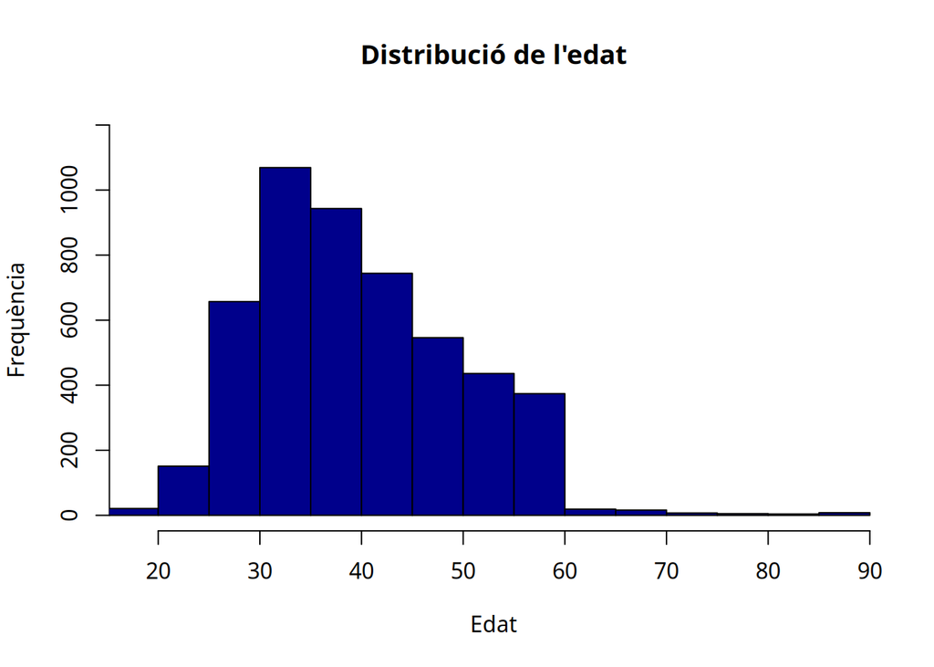

```r
hist(df$age,
     col = "blue4",
     xlim = c(min(df$age),
              max(df$age)),
              ylim = c(0, 1200),
              main = "Distribució de l'edat",
              xlab = "Edat",
              ylab = "Frequència")
```

Agruparem en quatre noves categories: Jove[0,25], Jove-Adult[26,45], Adult[46,65], Gran[+66].

Realitzem aquesta distinció pels següents motius:

- **Jove:** No solen tenir gaire poder adquisitiu propi
- **Jove-Adult:** És quan s’acostumen a fer més plans de futur i a tenir més capacitat econòmica
- **Adult:** Solen ser persones amb una vida estable i sense gaires canvis econòmics grans
- **Gran:** Persones amb la vida feta, sense canvis econòmics (Com que l’edat més gran registrada és 88 anys, entendrem que no tenim outliers)

La variable passarà a ser categòrica.

```r
df$age_num <- df$age
df$age <- cut(df$age,
              breaks = c(0, 25, 45, 65, max(df$age)),
              labels = c("Jove", "Jove-Adult", "Adult", "Gran"))
df$age <- as.factor(df$age)
```

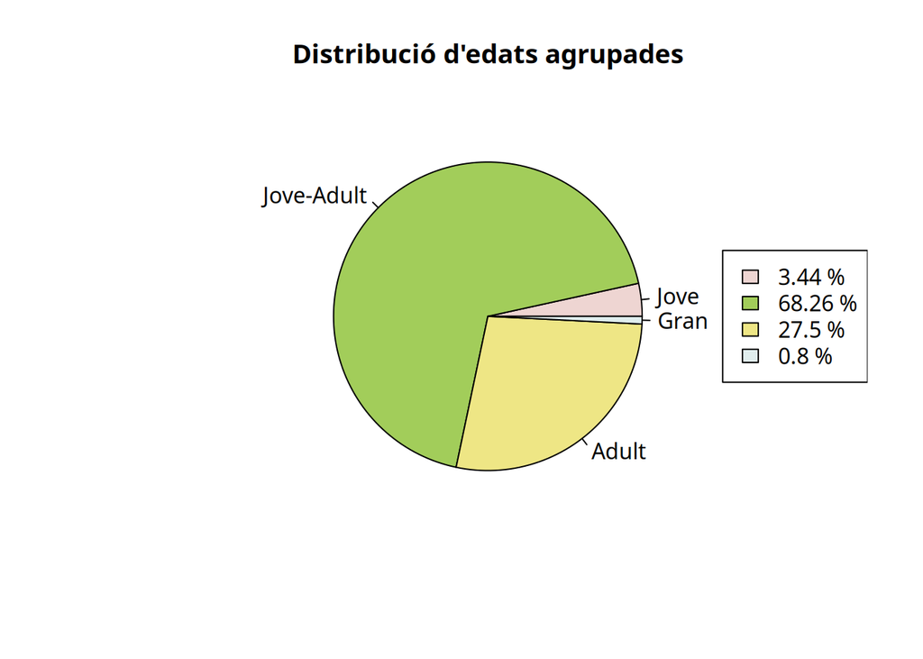

```r
pie(table(df$age),
        col = c("mistyrose2", "darkolivegreen3", "khaki2", "azure2"),
        main = "Distribució d'edats agrupades")
legend("right", fill = c("mistyrose2", "darkolivegreen3", "khaki2", "azure2") , legend = paste(100*prop.table(table(df$age)), "%"))
```

#### Job

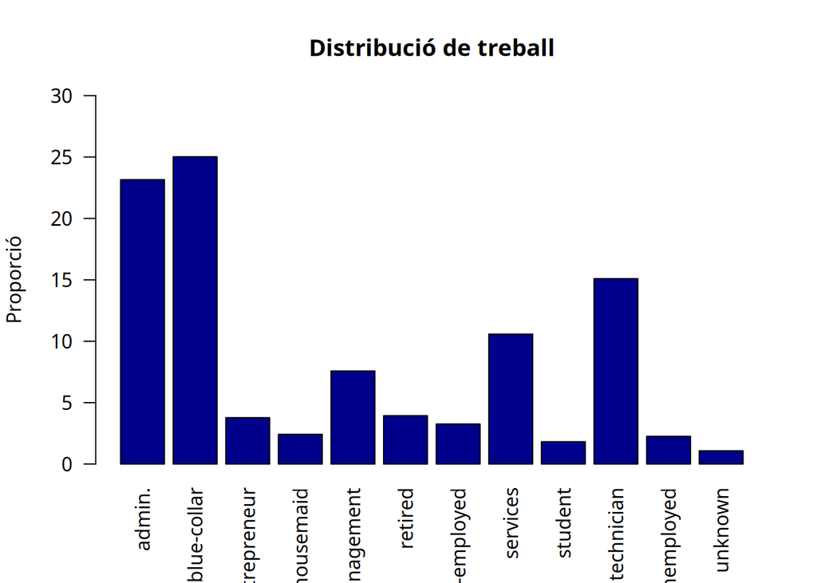

```r
barplot(100*prop.table(table(df$job)),
        ylim = c(0, 30),
        col = "blue4",
        main = "Distribució de treball",
        ylab = "Proporció",
        las = 2)
```

Les categories “retired”, “unemployed”, “student” i “housemaid” passaran a ser “unemployed”, ja que tenim en compte que són persones que no cotitzen.

```r
df$job <- as.character(df$job)
df$job <- ifelse(df$job %in% c("retired", "unemployed", "student", "housemaid"), "unemployed", df$job)
df$job <- ifelse(df$job == "entrepreneur", "self-employed", df$job)
df$job <- as.factor(df$job)
```

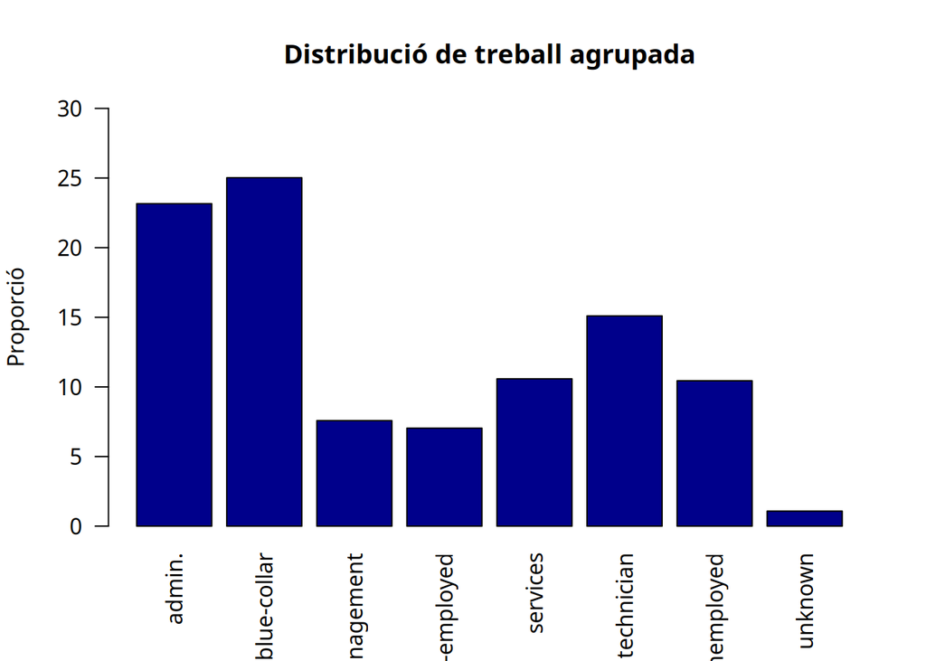

```r
barplot(100*prop.table(table(df$job)),
        ylim = c(0, 30),
        col = "blue4",
        main = "Distribució de treball agrupada",
        ylab = "Proporció",
        las = 2)
```

#### Marital

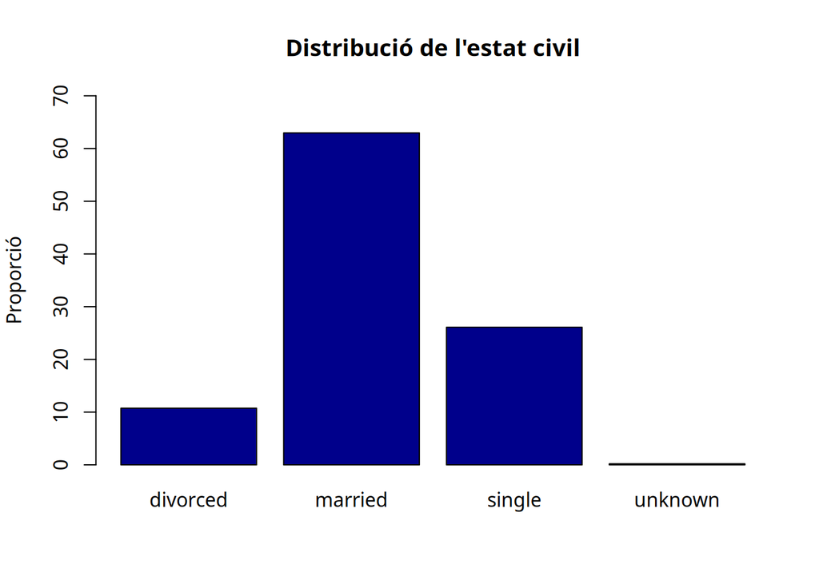

```r
barplot(100*prop.table(table(df$marital)),
        ylim = c(0, 70),
        main = "Distribució de l'estat civil",
        ylab = "Proporció",
        col = "blue4")
```

#### Education

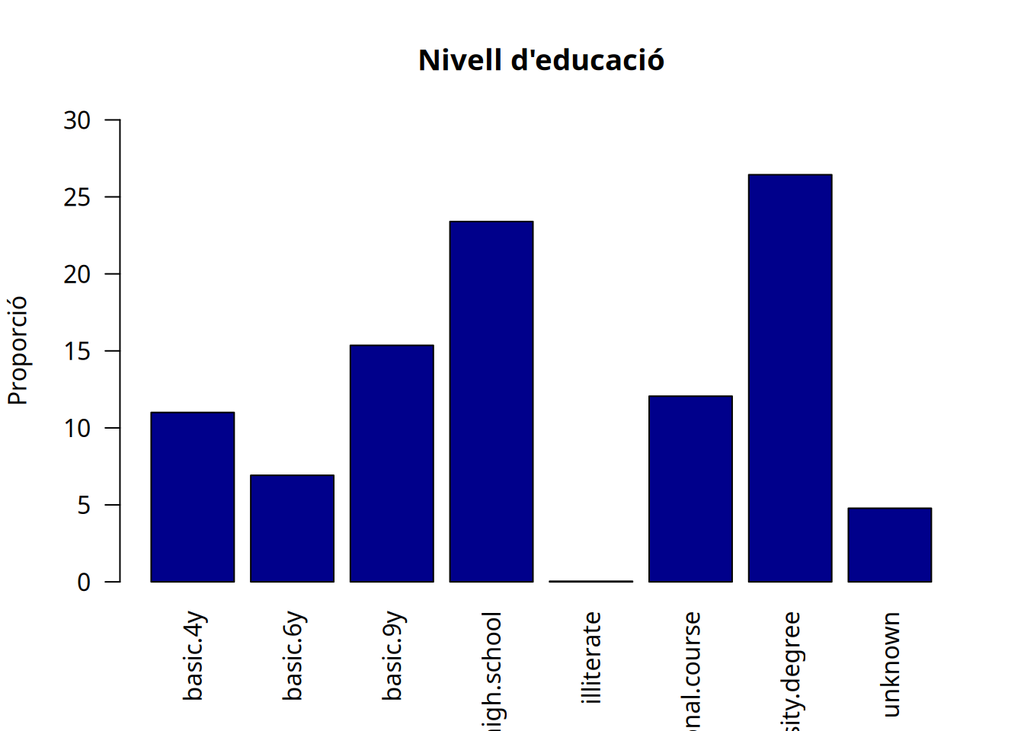

```r
barplot(100*prop.table(table(df$education)),
        ylim = c(0, 30),
        col = "blue4",
        main = "Nivell d'educació",
        ylab = "Proporció",
        las = 2)
```

Les categories “basic.4y”, “basic.6y”, “basic.9y” passaran a ser “basic”, ja que no aporta informació saber quin nivell de “basic” tenen.

```r
df$education <- as.character(df$education)
df$education <- ifelse(df$education %in% c("basic.4y", "basic.6y", "basic.9y"), "basic", df$education)
df$education <- as.factor(df$education)
```

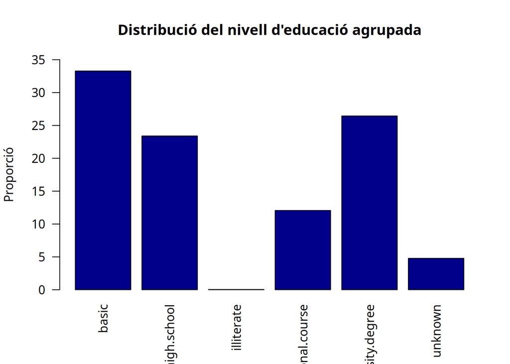

```r
barplot(100*prop.table(table(df$education)),
        ylim = c(0, 35),
        col = "blue4",
        main = "Distribució del nivell d'educació agrupada",
        ylab = "Proporció",
        las = 2)
```

#### Housing

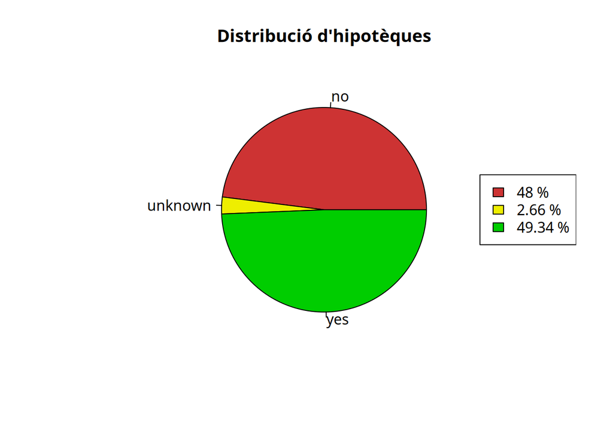

```r
pie(prop.table(table(df$housing)),
        col = c("brown3", "yellow2", "green3"),
        main = "Distribució d'hipotèques")
legend("right", fill = c("brown3", "yellow2", "green3") , legend = paste(100*prop.table(table(df$housing)), "%"))
```

#### Loan

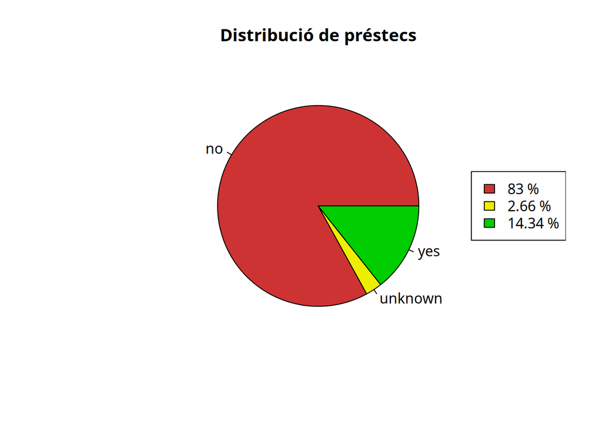

```r
pie(prop.table(table(df$loan)),
        col = c("brown3", "yellow2", "green3"),
        main = "Distribució de préstecs")
legend("right", fill = c("brown3", "yellow2", "green3") , legend = paste(100*prop.table(table(df$loan)), "%"))
```

#### Contact

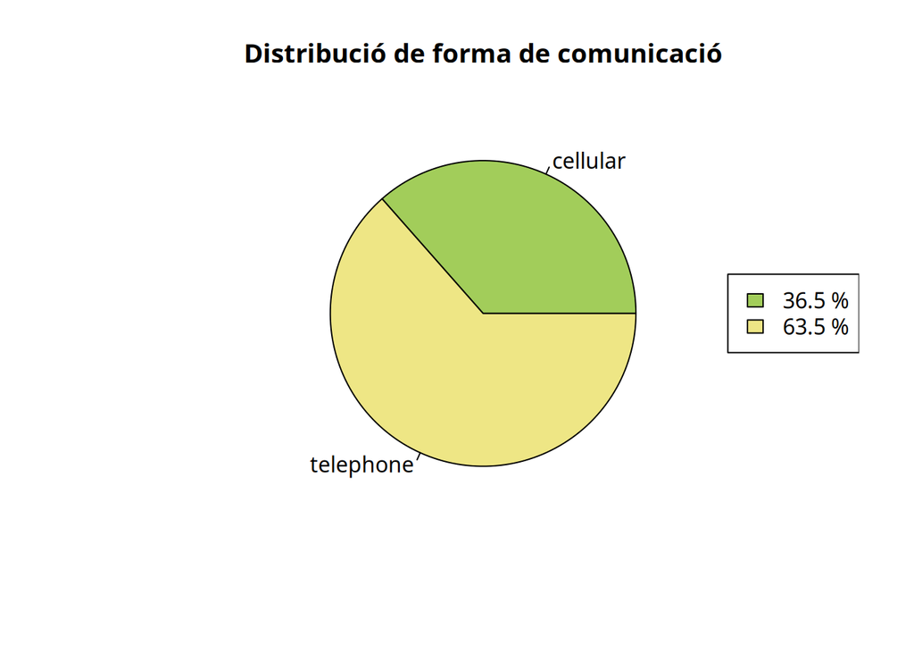

```r
pie(table(df$contact),
        col = c("darkolivegreen3", "khaki2"),
        main = "Distribució de forma de comunicació")
legend("right", fill = c("darkolivegreen3", "khaki2") , legend = paste(100*prop.table(table(df$contact)), "%"))
```

#### Month

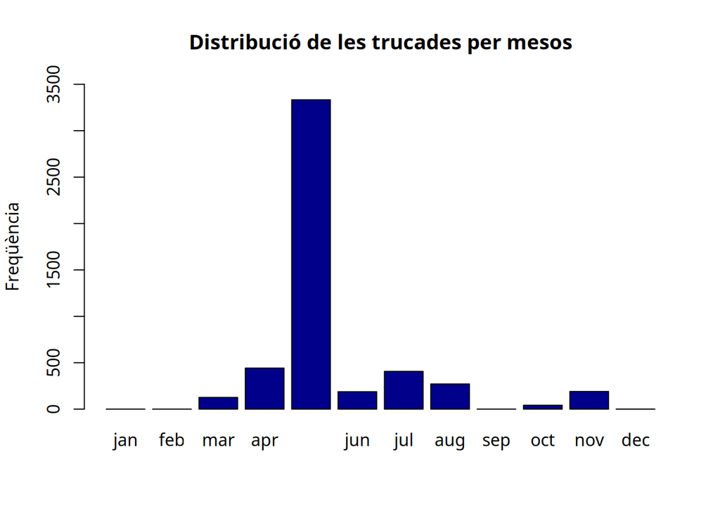

```r
mesos <- c("jan", "feb", "mar", "apr", "may", "jun", "jul", "aug", "sep", "oct", "nov", "dec")

df$month <- factor(df$month, levels = mesos)

barplot(table(df$month),
        ylim = c(0, 3500),
        col = "blue4",
        ylab = "Freqüència",
        main = "Distribució de les trucades per mesos")
```

#### Day of the week

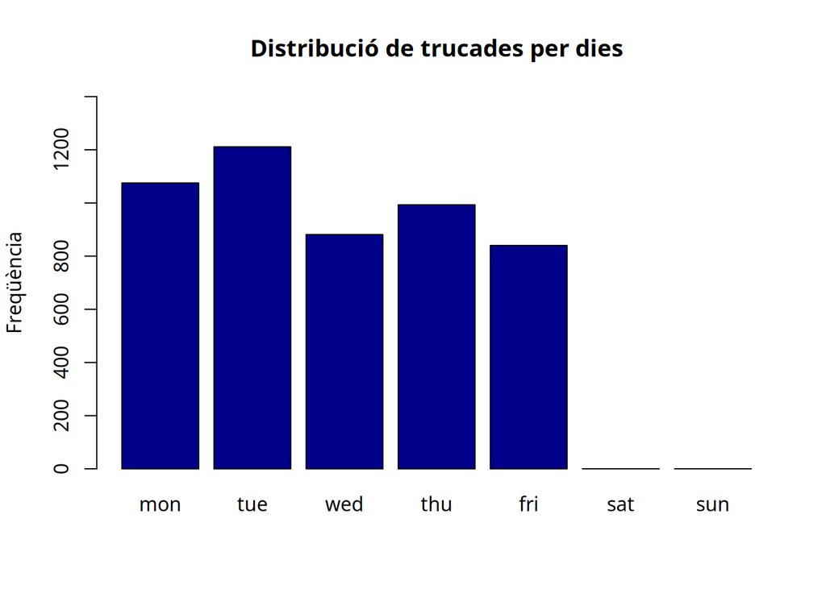

```r
days <- c("mon", "tue", "wed", "thu", "fri", "sat", "sun")

df$day_of_week <- factor(df$day_of_week, levels = days)

barplot(table(df$day_of_week),
        ylim = c(0, 1400),
        col = "blue4",
        ylab = "Freqüència",
        main = "Distribució de trucades per dies")
```

#### Duration

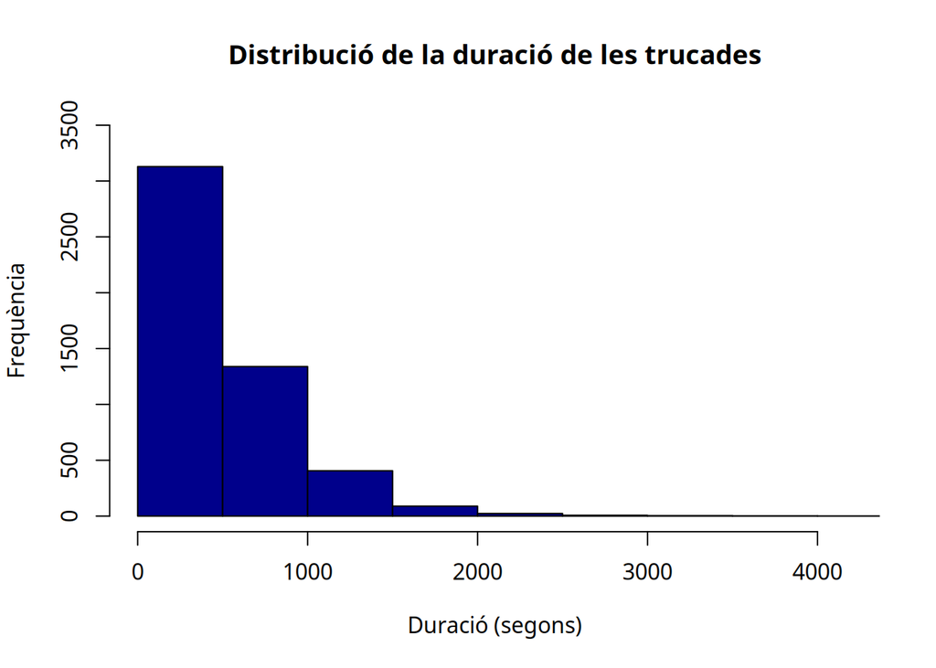

```r
hist(df$duration,
     col = "blue4",
     xlim = c(min(df$duration),
              max(df$duration)),
              ylim = c(0, 3500),
              main = "Distribució de la duració de les trucades",
              xlab = "Duració (segons)",
              ylab = "Frequència")
```

#### Campaign

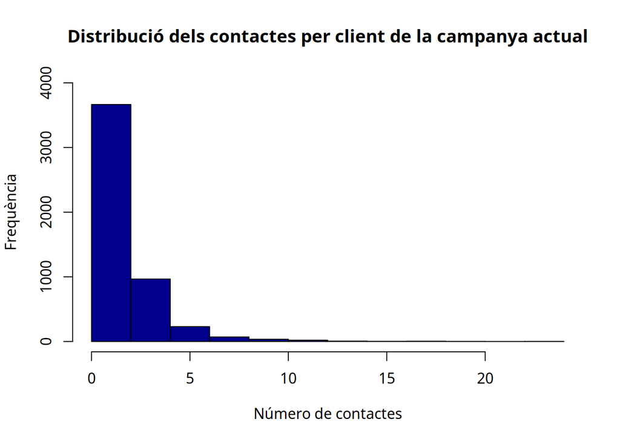

```r
hist(df$campaign,
     col = "blue4",
              ylim = c(0, 4000),
              main = "Distribució dels contactes per client de la campanya actual",
              xlab = "Número de contactes",
              ylab = "Frequència")
```

#### Pdays

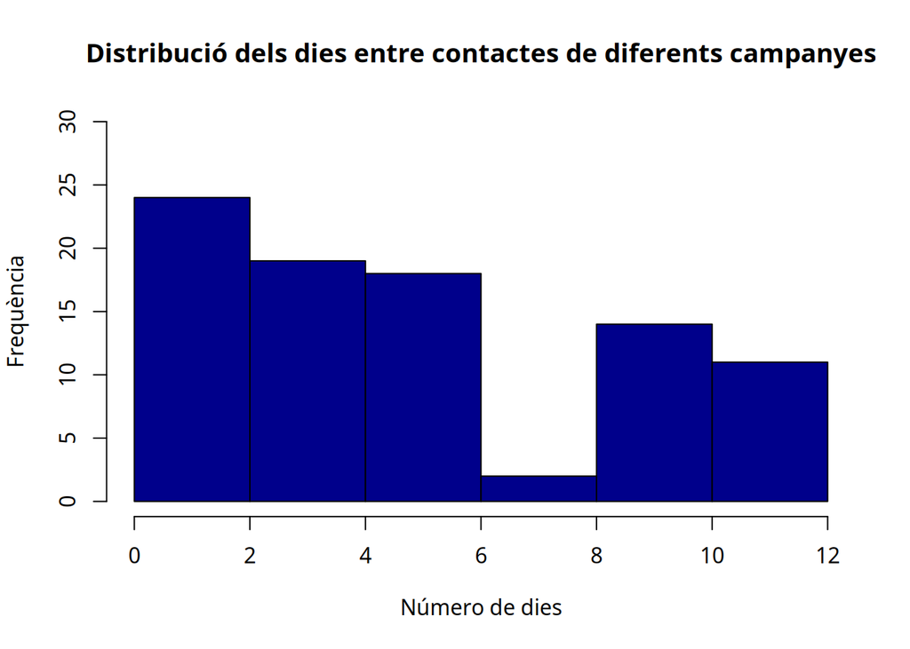

```r
pdays_aux <- subset(df$pdays, df$pdays != 999) #Deixem fora els valors 999 ja que no són vàlids
hist(pdays_aux,
     col = "blue4",
              ylim = c(0, 30),
              main = "Distribució dels dies entre contactes de diferents campanyes",
              xlab = "Número de dies",
              ylab = "Frequència")
```

#### Previous

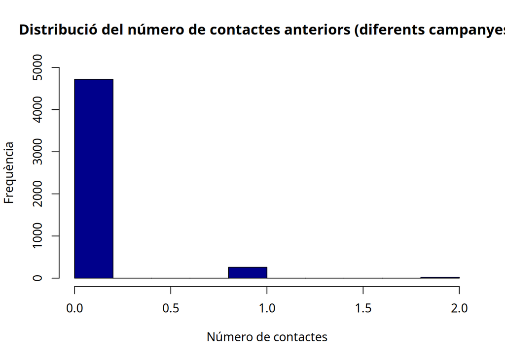

```r
hist(df$previous,
     col = "blue4",
              ylim = c(0, 5000),
              main = "Distribució del número de contactes anteriors (diferents campanyes)",
              xlab = "Número de contactes",
              ylab = "Frequència")
```

Ho passem a dos valors possibles: No[0] Yes[+1].

La variable passarà a ser categòrica.

```r
df <- df %>% mutate(previous = ifelse(previous >= 1, "Yes" , previous))
df <- df %>% mutate(previous = ifelse(previous == 0, "No" , previous))
df$previous <- as.factor(df$previous)
```

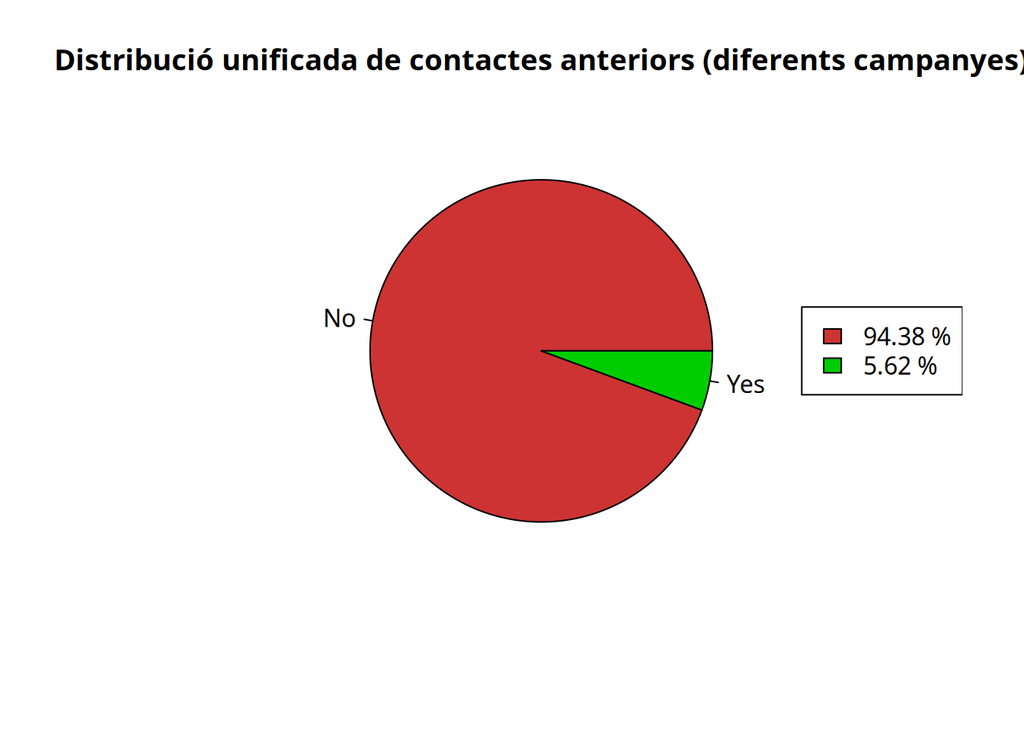

```r
pie(table(df$previous), main = "Distribució unificada de contactes anteriors (diferents campanyes)",
    col = c("brown3", "green3"))
legend("right", fill = c("brown3", "green3") , legend = paste(100*prop.table(table(df$previous)), "%"))
```

#### Poutcome

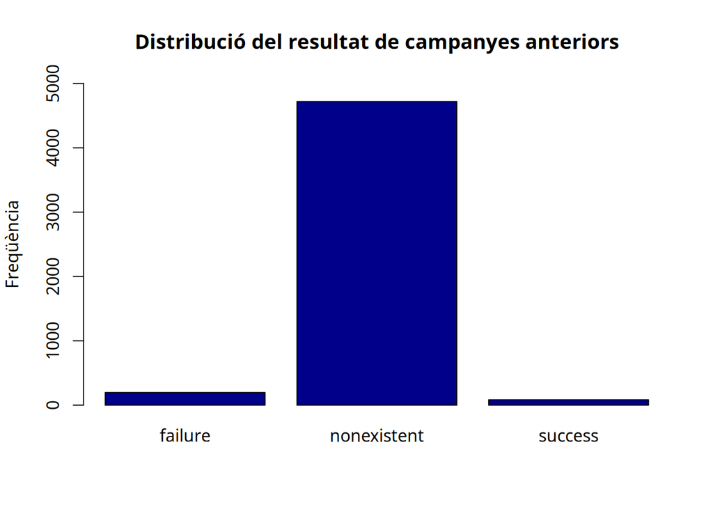

```r
barplot(table(df$poutcome),
        ylim = c(0, 5000),
        col = "blue4",
        ylab = "Freqüència",
        main = "Distribució del resultat de campanyes anteriors")
```

#### Employment variation rate

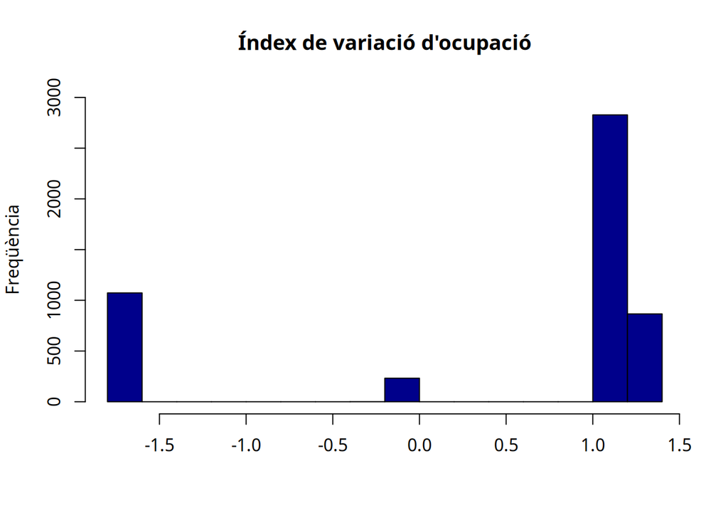

```r
hist(df$emp.var.rate,
     ylim = c(0, 3000),
        col = "blue4",
        xlab = "",
        ylab = "Freqüència",
        main = "Índex de variació d'ocupació")
```

#### Consumer price index

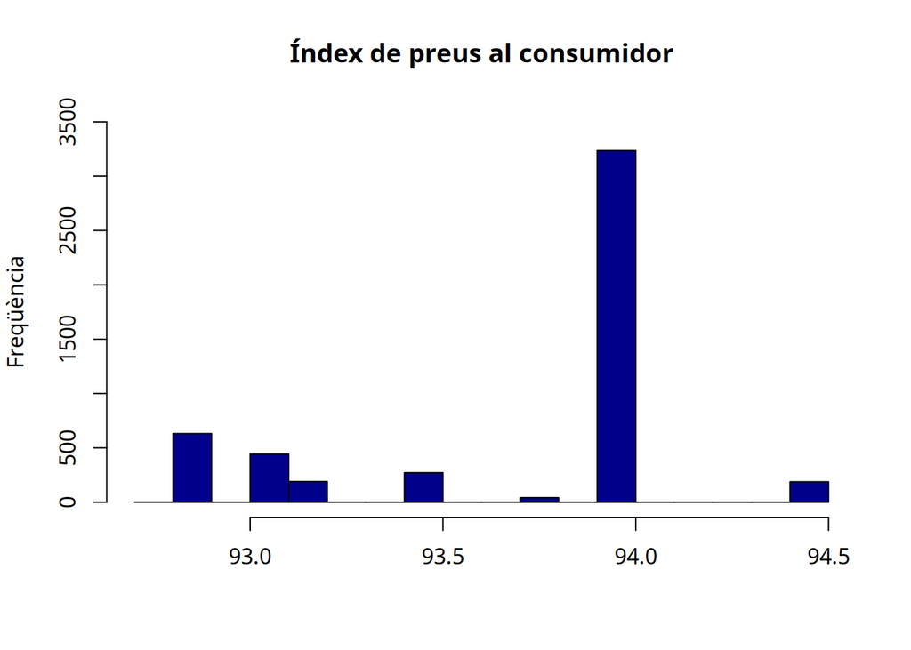

```r
hist(df$cons.price.idx,
     ylim = c(0, 3500),
        col = "blue4",
        xlab = "",
        ylab = "Freqüència",
        main = "Índex de preus al consumidor")
```

#### Consumer confidence index

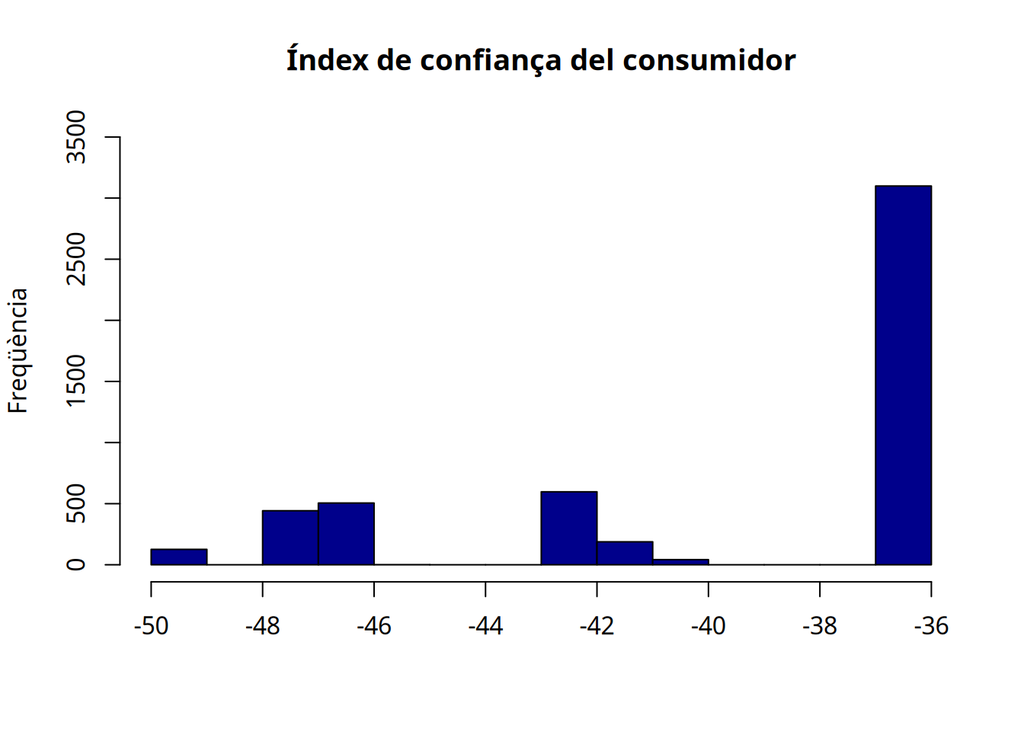

```r
hist(df$cons.conf.idx,
     ylim = c(0, 3500),
        col = "blue4",
        xlab = "",
        ylab = "Freqüència",
        main = "Índex de confiança del consumidor")
```

#### Euribor 3 month rate

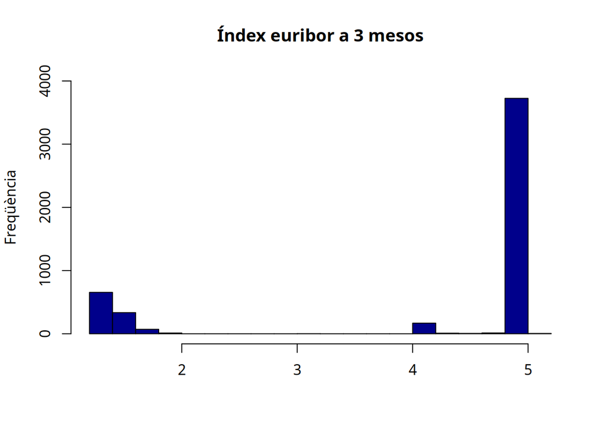

```r
hist(df$euribor3m,
     ylim = c(0, 4000),
        col = "blue4",
        xlab = "",
        ylab = "Freqüència",
        main = "Índex euribor a 3 mesos")
```

#### Number of employees

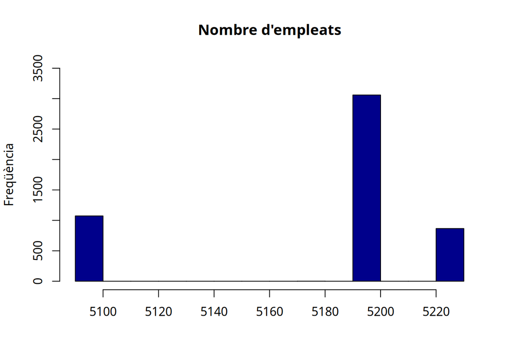

```r
hist(df$nr.employed,
     ylim = c(0, 3500),
        col = "blue4",
        xlab = "",
        ylab = "Freqüència",
        main = "Nombre d'empleats")
```

#### Subscribed deposit

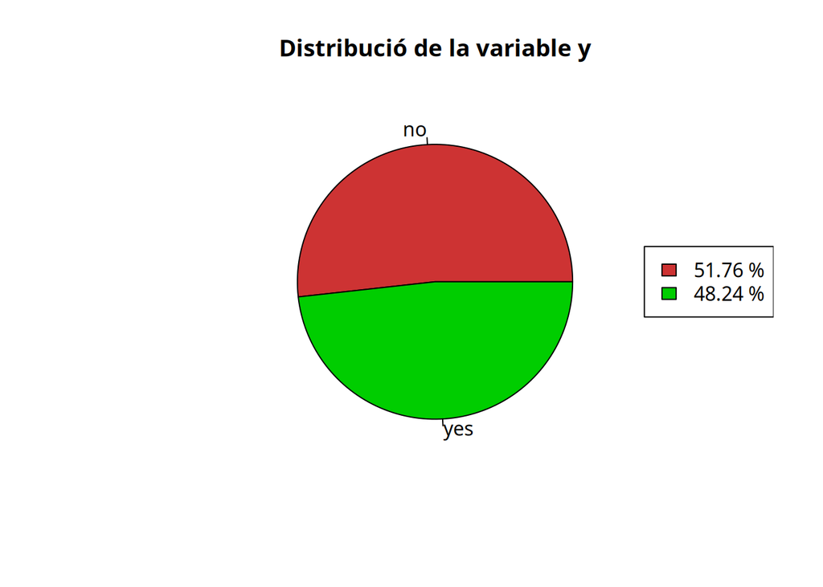

```r
pie(prop.table(table(df$y)),
        col = c("brown3", "green3"),
        main = "Distribució de la variable y")
legend("right", fill = c("brown3", "green3") , legend = paste(100*prop.table(table(df$y)), "%"))
```

## Qualitat de les dades

### Per variable

#### Nombre de missings

Passem tots els valors “unknown” a NA’s per tractar-los com a missings i contem el total de NA’s per variable.

```r
df[df == "unknown"] <- NA
colSums(is.na(df))
```

```
##            age            job        marital      education        default
##              0             54             10            239           1244
##        housing           loan        contact          month    day_of_week
##            133            133              0              0              0
##       duration       campaign          pdays       previous       poutcome
##              0              0              0              0              0
##   emp.var.rate cons.price.idx  cons.conf.idx      euribor3m    nr.employed
##              0              0              0              0              0
##              y        age_num
##              0              0
```

#### Nombre d’errors

1- Que una persona tingui pdays de 999 i que previous “yes” és una contradicció. Trobem el número de vegades que es dona aquesta situació. El nombre d’errors serà aquest multiplicat per dos, ja que els dos valors de la variable passen a ser errors.

```r
err_ind <- which(df$pdays == 999 & df$previous == "Yes")
length(err_ind)
```

```
## [1] 193
```

```r
df$previous[err_ind]<-NA
df$pdays[err_ind]<-NA
```

No hem trobat més possibles errors.

#### Nombre d’outliers

Busquem els outliers de les variables utilitzant la tècnica del tercer quantil.

Per la variable “duration”.

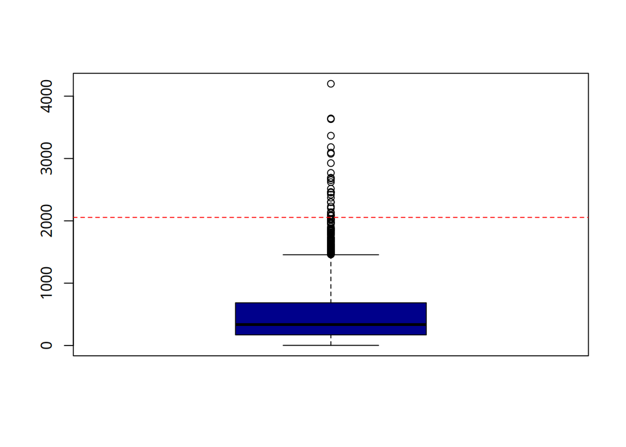

```r
boxplot(df$duration, col = "blue4")
treshold <- quantile(df$duration, 0.75)*3
abline(h = treshold, col = "red", lty = "dashed")
```

Trobem el nombre d’outliers

```r
out_dur <- which(df$duration > treshold)
length(out_dur)
```

```
## [1] 30
```

Per la variable “campaign”.

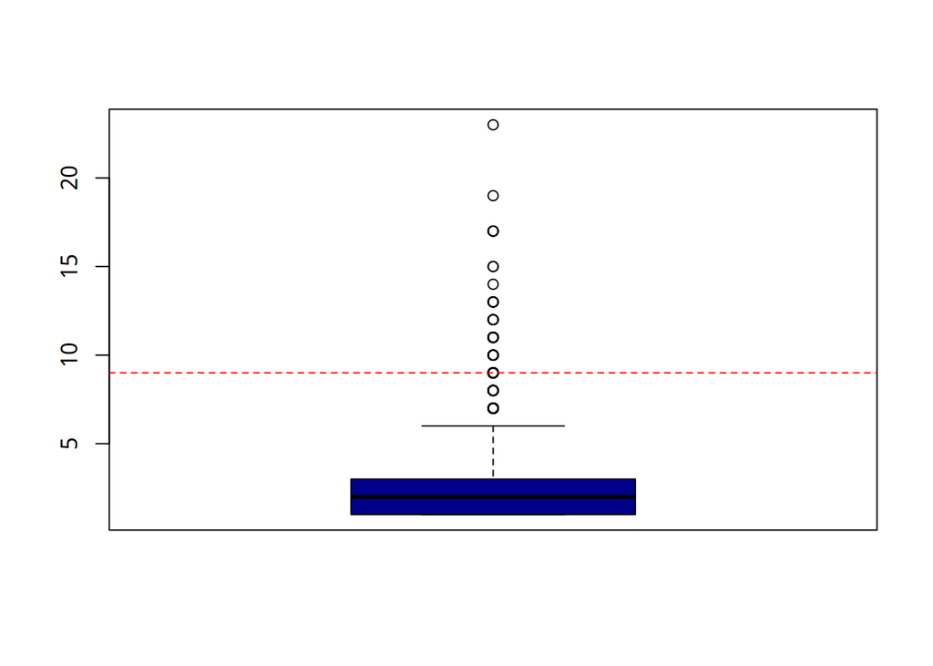

```r
boxplot(df$campaign, col = "blue4")
treshold <- quantile(df$campaign, 0.75)*3
abline(h = treshold, col = "red", lty = "dashed")
```

Trobem el nombre d’outliers

```r
out_camp <- which(df$campaign > treshold)
length(out_camp)
```

```
## [1] 45
```

#### Ranking de variables amb més valors NA i errors

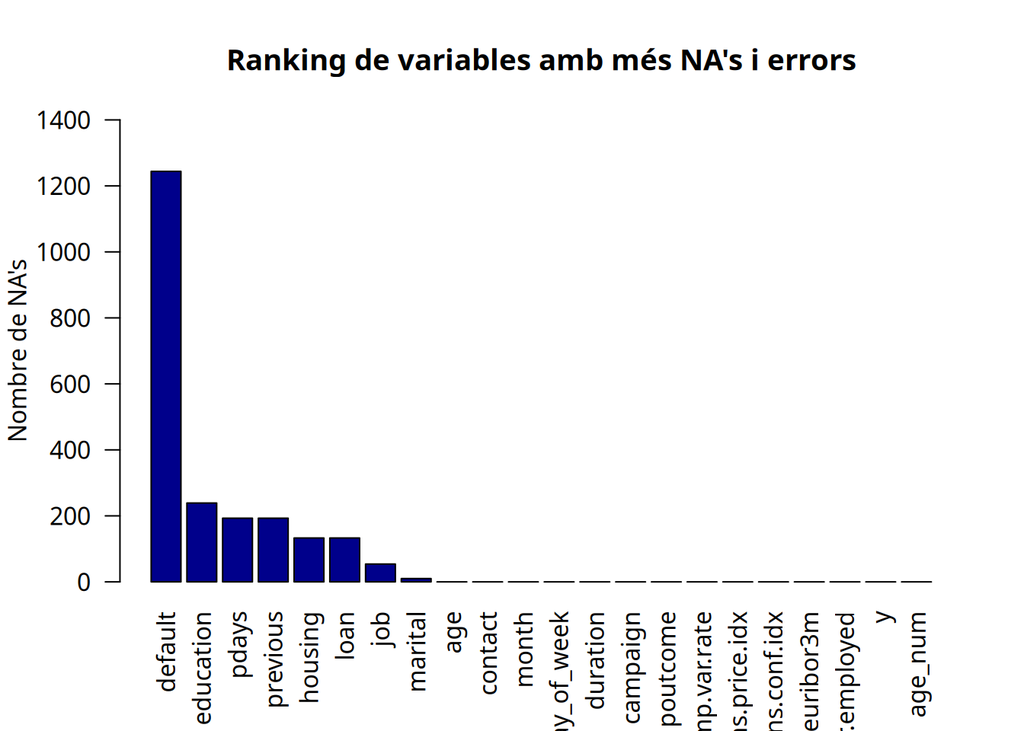

```r
nas_per_var <- data.frame(num_nas = colSums(is.na(df)),
                          variable = names(df))

# Ordenem el data frame per nombre de NA's descendent
nas_per_var <- nas_per_var[order(-nas_per_var$num_nas),]

# Fem el gràfic de barres
barplot(nas_per_var$num_nas,
        names.arg = nas_per_var$variable,
        ylim = c(0, 1400),
        col = "blue4",
        ylab = "Nombre de NA's",
        main = "Ranking de variables amb més NA's i errors",
        las = 2)
```

### Per individus

Tornem a recuperar els valors de pdays i previous per no contar-los com a missings, sino com a errors.

```r
df$pdays[err_ind]<-999
df$previous[err_ind]<-"Yes"
```

#### Nombre de missings

```r
n_missings <- rowSums(is.na(df))
table(n_missings)
```

```
## n_missings
##    0    1    2    3    4
## 3506 1250  174   65    5
```

A la taula podem veure la distribució del nombre de missings pel nombre d’individus que tenen aquest nombre de missings.

#### Nombre d’errors

Com que només hem detectat un error, que pdays sigui 999 i previous sigui “yes”, sabem que tenim 193 combinacions de valors que compleixen l’error. Per tant, tindrem que 193 individus tenen 2 errors (1 a pdays i 1 a previous) i la resta (4807) no tenen cap error.

Esborrarem la variable pdays ja que no ens aporta cap informació adicional.

```r
df <- subset(df, select = -pdays)
```

#### Nombre d’outliers

```r
out_ind <- rowSums(cbind(as.numeric(df$duration %in% out_dur), as.numeric(df$campaign %in% out_camp)))
table(out_ind)
```

```
## out_ind
##    0    1
## 4934   66
```

Igual que amb els missings, a la taula podem veure la distribució del nombre d’outliers pel nombre d’individus que tenen aquest nombre de desviacions.

#### Afegim variable que conti els NA

Abans de contar els missings, passarem a NA’s els index de les variables que hem trobat errors o outliers.

```r
df$campaign[out_camp]<-NA
df$duration[out_dur]<-NA
df$previous[err_ind]<-NA
```

Creem la nova variable i contem els NA’s

```r
df$na_count <- apply(df, 1, function(x) sum(is.na(x)))
```

#### Relació entre grup d’edat i valors atípics

Respecte els grups d’edat que hem definit anteriorment, volem veure quin d’aquests grups és més propenç a tenir missings (dins dels missings hi ha outliers i errors).

```r
missings_edat <- aggregate(df$na_count, by = list(df$age), sum)
missings_edat <- missings_edat[order(missings_edat$x, decreasing = TRUE), ]
names(missings_edat) <- c("Grup d'edat", "Missings")
missings_edat
```

```
##   Grup d'edat Missings
## 2  Jove-Adult     1257
## 3       Adult      758
## 1        Jove       53
## 4        Gran       13
```

A la taula podem veure la distribució de missings per grups d’edat (La primera columna sols és un identificador del grup d’edat, no aporta cap informació).

### Imputació de missings

#### Variables categòriques

Imputem tots els NAs que tenim en el conjunt de variables categòriques (var_cat).

Dades abans d’imputar.

```r
var_cat <- c("age", "job", "marital", "education", "housing", "loan", "contact", "month", "day_of_week", "previous", "poutcome", "y") #Obviarem la variable "default" ja que té masses missings per imputar
summary(df[,var_cat])
```

```
##          age                job           marital
##  Jove      : 172   blue-collar:1251   divorced: 537
##  Jove-Adult:3413   admin.     :1158   married :3148
##  Adult     :1375   technician : 755   single  :1305
##  Gran      :  40   services   : 529   unknown :   0
##                    unemployed : 522   NA's    :  10
##                    (Other)    : 731
##                    NA's       :  54
##                education       housing          loan           contact
##  basic              :1664   no     :2400   no     :4150   cellular :1825
##  high.school        :1170   unknown:   0   unknown:   0   telephone:3175
##  illiterate         :   2   yes    :2467   yes    : 717
##  professional.course: 603   NA's   : 133   NA's   : 133
##  university.degree  :1322
##  unknown            :   0
##  NA's               : 239
##      month      day_of_week previous           poutcome      y
##  may    :3333   mon:1075    No  :4719   failure    : 197   no :2588
##  apr    : 442   tue:1211    Yes :  88   nonexistent:4719   yes:2412
##  jul    : 407   wed: 881    NA's: 193   success    :  84
##  aug    : 271   thu: 993
##  nov    : 190   fri: 840
##  jun    : 188   sat:   0
##  (Other): 169   sun:   0
```

Dades després d’imputar.

```r
res.immca<-imputeMCA(df[,var_cat],ncp = length(var_cat)-1)
summary(res.immca$completeObs)
```

```
##          age                  job           marital
##  Jove      : 172   admin.       :1169   divorced: 537
##  Jove-Adult:3413   blue-collar  :1292   married :3158
##  Adult     :1375   management   : 379   single  :1305
##  Gran      :  40   self-employed: 352
##                    services     : 530
##                    technician   : 756
##                    unemployed   : 522
##                education    housing     loan           contact
##  basic              :1767   no :2473   no :4283   cellular :1825
##  high.school        :1212   yes:2527   yes: 717   telephone:3175
##  illiterate         :   2
##  professional.course: 632
##  university.degree  :1387
##
##
##      month      day_of_week previous          poutcome      y
##  may    :3333   mon:1075    No :4912   failure    : 197   no :2588
##  apr    : 442   tue:1211    Yes:  88   nonexistent:4719   yes:2412
##  jul    : 407   wed: 881               success    :  84
##  aug    : 271   thu: 993
##  nov    : 190   fri: 840
##  jun    : 188
##  (Other): 169
```

```r
df[,var_cat]<-res.immca$completeObs
```

#### Variables numèriques

Imputem tots els NAs que tenim en el conjunt de variables numeriques (var_num).

Dades abans de imputar.

```r
var_num <- c("duration", "campaign", "emp.var.rate", "cons.conf.idx", "cons.price.idx", "euribor3m", "nr.employed")
summary(df[,var_num])
```

```
##     duration         campaign      emp.var.rate     cons.conf.idx
##  Min.   :   3.0   Min.   :1.000   Min.   :-1.8000   Min.   :-50.00
##  1st Qu.: 170.0   1st Qu.:1.000   1st Qu.:-0.1000   1st Qu.:-42.70
##  Median : 334.0   Median :2.000   Median : 1.1000   Median :-36.40
##  Mean   : 463.6   Mean   :2.065   Mean   : 0.4737   Mean   :-39.63
##  3rd Qu.: 676.8   3rd Qu.:3.000   3rd Qu.: 1.1000   3rd Qu.:-36.40
##  Max.   :2033.0   Max.   :9.000   Max.   : 1.4000   Max.   :-36.10
##  NA's   :30       NA's   :45
##  cons.price.idx    euribor3m      nr.employed
##  Min.   :92.76   Min.   :1.244   Min.   :5099
##  1st Qu.:93.20   1st Qu.:4.343   1st Qu.:5191
##  Median :93.99   Median :4.856   Median :5191
##  Mean   :93.72   Mean   :4.100   Mean   :5178
##  3rd Qu.:93.99   3rd Qu.:4.857   3rd Qu.:5191
##  Max.   :94.47   Max.   :5.045   Max.   :5228
##
```

Dades després d’imputar.

```r
res.impca<-imputePCA(df[,var_num],ncp = length(var_num)-1)
summary(res.impca$completeObs)
```

```
##     duration         campaign      emp.var.rate     cons.conf.idx
##  Min.   :   3.0   Min.   :1.000   Min.   :-1.8000   Min.   :-50.00
##  1st Qu.: 171.0   1st Qu.:1.000   1st Qu.:-0.1000   1st Qu.:-42.70
##  Median : 336.0   Median :2.000   Median : 1.1000   Median :-36.40
##  Mean   : 464.8   Mean   :2.068   Mean   : 0.4737   Mean   :-39.63
##  3rd Qu.: 680.0   3rd Qu.:3.000   3rd Qu.: 1.1000   3rd Qu.:-36.40
##  Max.   :2033.0   Max.   :9.000   Max.   : 1.4000   Max.   :-36.10
##  cons.price.idx    euribor3m      nr.employed
##  Min.   :92.76   Min.   :1.244   Min.   :5099
##  1st Qu.:93.20   1st Qu.:4.343   1st Qu.:5191
##  Median :93.99   Median :4.856   Median :5191
##  Mean   :93.72   Mean   :4.100   Mean   :5178
##  3rd Qu.:93.99   3rd Qu.:4.857   3rd Qu.:5191
##  Max.   :94.47   Max.   :5.045   Max.   :5228
```

```r
df[,var_num ]<-res.impca$completeObs
```

## Profiling

### Variables categòriques

Fem el profiling de la variable “y”.

```r
res.catdes<-catdes(df,grep("^y$", colnames(df)), proba=0.05)
res.catdes$test.chi2 # relació entre les variables y la variable resposta
```

```
##                  p.value df
## contact     0.000000e+00  1
## month       0.000000e+00  8
## poutcome    4.272175e-70  2
## default     1.928184e-43  1
## day_of_week 3.199213e-31  4
## marital     1.423436e-23  2
## previous    1.085202e-22  1
## age         2.484262e-22  3
## education   3.990582e-22  4
## job         4.547525e-15  6
## housing     7.595941e-11  1
```

```r
res.catdes$category
```

```
## $no
##                              Cla/Mod    Mod/Cla Global       p.value     v.test
## month=may                   77.64776 100.000000  66.66  0.000000e+00        Inf
## contact=telephone           81.51181 100.000000  63.50  0.000000e+00        Inf
## poutcome=nonexistent        54.84213 100.000000  94.38  1.396630e-93  20.521050
## default=NA                  68.72990  33.037094  24.88  2.743947e-44  13.959750
## previous=No                 52.68730 100.000000  98.24  5.977949e-29  11.166052
## day_of_week=tue             64.07927  29.984544  24.22  3.778666e-23   9.909677
## marital=married             56.71311  69.204019  63.16  4.208146e-20   9.182598
## education=basic             59.59253  40.687790  35.34  2.212776e-16   8.209952
## job=blue-collar             59.98452  29.945904  25.84  5.702943e-12   6.886880
## housing=no                  56.40922  53.902628  49.46  7.492004e-11   6.510462
## age=Adult                   57.67273  30.641422  27.50  2.478903e-07   5.159288
## day_of_week=mon             56.74419  23.570325  21.50  2.206025e-04   3.694174
## job=services                58.49057  11.978362  10.60  1.022175e-03   3.284351
## job=unemployed              46.55172   9.389490  10.44  1.196767e-02  -2.513096
## job=technician              47.08995  13.755796  15.12  5.330588e-03  -2.786346
## day_of_week=fri             47.14286  15.301391  16.80  3.355222e-03  -2.933168
## job=admin.                  45.16681  20.401855  23.38  2.586795e-07  -5.151305
## day_of_week=wed             43.47333  14.799073  17.62  5.911229e-08  -5.421466
## day_of_week=thu             42.59819  16.344668  19.86  1.088140e-10  -6.454169
## housing=yes                 47.21013  46.097372  50.54  7.492004e-11  -6.510462
## age=Jove                    27.32558   1.816074   3.44  4.108495e-11  -6.600111
## age=Gran                     0.00000   0.000000   0.80  1.832334e-13  -7.360492
## month=oct                    0.00000   0.000000   0.84  4.189623e-14  -7.554968
## education=university.degree 41.31218  22.140649  27.74  4.843918e-20  -9.167439
## marital=single              39.84674  20.092736  26.10  1.101467e-23 -10.032102
## poutcome=success             0.00000   0.000000   1.68  1.190303e-27 -10.897069
## previous=Yes                 0.00000   0.000000   1.76  5.977949e-29 -11.166052
## month=mar                    0.00000   0.000000   2.52  2.269537e-41 -13.472530
## default=no                  46.13951  66.962906  75.12  2.743947e-44 -13.959750
## month=jun                    0.00000   0.000000   3.76  5.976573e-62 -16.609220
## month=nov                    0.00000   0.000000   3.80  1.276337e-62 -16.701583
## poutcome=failure             0.00000   0.000000   3.94  5.700944e-65 -17.021382
## month=aug                    0.00000   0.000000   5.42  3.904937e-90 -20.131561
## month=jul                    0.00000   0.000000   8.14 5.437191e-138 -25.004681
## month=apr                    0.00000   0.000000   8.84 1.155522e-150 -26.143923
## contact=cellular             0.00000   0.000000  36.50  0.000000e+00       -Inf
##
## $yes
```

[output cut: 22 more lines]

```
## job=technician               52.91005 16.583748  15.12  5.330588e-03   2.786346
## job=unemployed               53.44828 11.567164  10.44  1.196767e-02   2.513096
## job=services                 41.50943  9.121061  10.60  1.022175e-03  -3.284351
## day_of_week=mon              43.25581 19.278607  21.50  2.206025e-04  -3.694174
## age=Adult                    42.32727 24.129353  27.50  2.478903e-07  -5.159288
## housing=no                   43.59078 44.693201  49.46  7.492004e-11  -6.510462
## job=blue-collar              40.01548 21.434494  25.84  5.702943e-12  -6.886880
## education=basic              40.40747 29.601990  35.34  2.212776e-16  -8.209952
## marital=married              43.28689 56.674959  63.16  4.208146e-20  -9.182598
## day_of_week=tue              35.92073 18.034826  24.22  3.778666e-23  -9.909677
## previous=No                  47.31270 96.351575  98.24  5.977949e-29 -11.166052
## default=NA                   31.27010 16.127695  24.88  2.743947e-44 -13.959750
## poutcome=nonexistent         45.15787 88.349917  94.38  1.396630e-93 -20.521050
## month=may                    22.35224 30.887231  66.66  0.000000e+00       -Inf
## contact=telephone            18.48819 24.336650  63.50  0.000000e+00       -Inf
```

```r
res.catdes$quanti  # Global association to numeric variables
```

```
## $no
##                    v.test Mean in category Overall mean sd in category
## cons.conf.idx   53.169902      -36.4000000   -39.626300   0.000000e+00
## cons.price.idx  43.816029       93.9940000    93.722201   0.000000e+00
## euribor3m       38.675184        4.8560696     4.100294   8.352458e-04
## emp.var.rate    37.512348        1.1000000     0.473680   0.000000e+00
## nr.employed     22.081559     5191.0000000  5177.923760   0.000000e+00
## age_num          6.658336       41.0641422    40.159000   8.885746e+00
## na_count         6.469584        0.4741113     0.416200   6.947767e-01
## campaign        -3.462143        2.0011383     2.067662   1.294232e+00
## duration       -42.854275      243.9352241   464.790464   2.007280e+02
##                 Overall sd       p.value
## cons.conf.idx    4.4439989  0.000000e+00
## cons.price.idx   0.4543068  0.000000e+00
## euribor3m        1.4311845  0.000000e+00
## emp.var.rate     1.2228047 5.794591e-308
## nr.employed     43.3698783 4.754022e-108
## age_num          9.9560293  2.769453e-11
## na_count         0.6555742  9.827295e-11
## campaign         1.4072408  5.358914e-04
## duration       377.4405914  0.000000e+00
##
## $yes
##                    v.test Mean in category Overall mean sd in category
## duration        42.854275      701.7611779   464.790464    378.9391840
## campaign         3.462143        2.1390405     2.067662      1.5159317
## na_count        -6.469584        0.3540630     0.416200      0.6045811
## age_num         -6.658336       39.1878109    40.159000     10.9058598
## nr.employed    -22.081559     5163.8933665  5177.923760     59.3196912
## emp.var.rate   -37.512348       -0.1983416     0.473680      1.4923455
## euribor3m      -38.675184        3.2893702     4.100294      1.7249824
## cons.price.idx -43.816029       93.4305701    93.722201      0.5133574
## cons.conf.idx  -53.169902      -43.0880182   -39.626300      4.2174971
##                 Overall sd       p.value
## duration       377.4405914  0.000000e+00
## campaign         1.4072408  5.358914e-04
## na_count         0.6555742  9.827295e-11
## age_num          9.9560293  2.769453e-11
## nr.employed     43.3698783 4.754022e-108
## emp.var.rate     1.2228047 5.794591e-308
## euribor3m        1.4311845  0.000000e+00
## cons.price.idx   0.4543068  0.000000e+00
## cons.conf.idx    4.4439989  0.000000e+00
```

```r
res.catdes$quali # Global association to factors
```

[output not shown]

**Poutcome**: La variable Poutcome (resultat de la campanya de màrqueting anterior) també està fortament relacionada amb la variable target “y”. Si el resultat de la campanya anterior va ser exitós, és més probable que el client contracti el dipòsit a termini.

**Duration**: Aquesta variable és una altra que es veu altament relacionada amb el resultat. Això pot ser degut a que com més temps duri la trucada, és més probable que l’agent de vendes hagi tingut l’oportunitat de persuadir el client i fer-li una oferta més atractiva.

### Variables numériques

```r
#duration
res.condes<-condes(df,grep("^duration$", colnames(df)), proba=0.05)
res.condes$test.chi2 # relació entre les variables y la variable resposta
```

[output not shown]

```r
res.condes$category
```

```
##                               Estimate       p.value
## y=yes                        228.91298  0.000000e+00
## contact=cellular             165.16324 2.093855e-214
## month=jul                    333.85272 3.965288e-118
## month=aug                    280.72756  5.068452e-57
## month=jun                    341.05236  1.938499e-53
## month=nov                    208.13506  2.463898e-25
## poutcome=failure             106.55349  7.581864e-13
## day_of_week=wed               50.66271  1.397880e-06
## default=no                    21.12415  6.195630e-04
## marital=single                20.58647  2.151955e-03
## day_of_week=thu               26.20140  3.632670e-03
## housing=yes                   11.24417  3.517575e-02
## day_of_week=fri               19.96409  3.575222e-02
## age=Jove-Adult                57.19128  3.944233e-02
## housing=no                   -11.24417  3.517575e-02
## education=university.degree  -16.52057  1.044162e-02
## month=oct                   -245.16912  2.484858e-03
## marital=married              -19.32388  2.432148e-03
## day_of_week=mon              -36.34532  2.098132e-03
## job=unemployed               -47.45417  1.484963e-03
## age=Gran                    -146.97090  9.341034e-04
## default=NA                   -21.12415  6.195630e-04
## day_of_week=tue              -60.48287  3.926094e-09
## month=mar                   -265.09390  3.802976e-09
## poutcome=nonexistent         -90.99622  3.314190e-12
## month=may                   -178.18275 5.706054e-198
## contact=telephone           -165.16324 2.093855e-214
## y=no                        -228.91298  0.000000e+00
```

```r
res.condes$quanti  # Global association to numeric variables
```

```
##                correlation      p.value
## campaign        0.09357119 3.371081e-11
## nr.employed     0.05776931 4.364235e-05
## age_num        -0.05293015 1.808138e-04
## emp.var.rate   -0.08878741 3.193708e-10
## euribor3m      -0.12017447 1.509610e-17
## cons.price.idx -0.18889226 2.199788e-41
## cons.conf.idx  -0.29184702 9.343997e-99
```

```r
res.condes$quali # Global association to factors
```

```
##                       R2       p.value
## month       0.2687566917  0.000000e+00
## y           0.3673712587  0.000000e+00
## contact     0.1775236255 2.093855e-214
## day_of_week 0.0126405296  5.186401e-13
## poutcome    0.0108893480  1.316225e-12
## default     0.0023416784  6.195630e-04
## age         0.0027889411  2.967867e-03
## marital     0.0020923915  5.335796e-03
## housing     0.0008873747  3.517575e-02
## job         0.0026763395  3.729645e-02
```

**y**: Hi ha una forta relació amb la variable categòrica y. En particular, té sentit que una duració elevada de la trucada vingui de la ma d’un resultat positiu, perquè l’agent de vendes va poder explicar i vendre el producte més estona.

**Contacte**: La forma de contacte utilitzada en l’última campanya de màrqueting té una alta correlació amb la durada de la trucada. En particular, els clients contactats per telèfon mòbil tendeixen a tenir una taxa més alta de contractació del servei/producte. Això implica una relació creuada amb la duració com ja hem comentat.

## Outliers multivariants

```r
# Perform multivariate outlier analysis using Moutlier function
outliers <- Moutlier(df[, c("age_num", "duration")], quantile= 0.995)
```

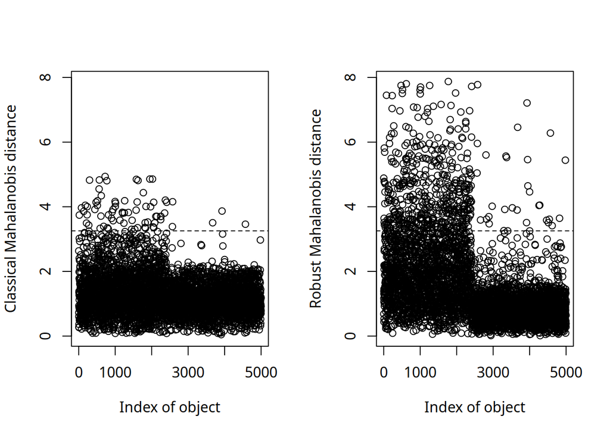

```r
top5 <- order(outliers$md, decreasing=TRUE)[1:5]
print(top5)
```

```
## [1]  724 1951 2023 1581  566
```

```r
outliers$cutoff
```

```
## [1] 3.255247
```

A la nostra execució final, hem determinat que els nostres individus a destacar que siguin multivariate outliers són els que tenen els identificadors següents:

```
724 1951 2023 1581  566
```

## Exportació

Una vegada hem netejat i triat les nostres dades, exportarem el nou dataset amb el següent codi, que ens guarda el nou conjunt de dades en el directori actual.

```r
write.csv(df, "./bank-additional-clean.csv", row.names = FALSE)
```